# Weight Lift Project

Carolina Rios-Trujillo

## Introduction

According to the information taken from this site (https://www.coursera.org/learn/practical-machine-learning/supplement/PvInj/course-project-instructions-read-first), six male participants aged between 20-28 years, with little weight lifting experience were asked to perform 10 repetitions of the dumbbell biceps curl in five different fashions: exactly according to the specification (Class A), throwing the elbows to the front (Class B), lifting the dumbbell only halfway (Class C), lowering the dumbbell only halfway (Class D) and throwing the hips to the front (Class E). Class A corresponds to the specified execution of the exercise, while the other 4 classes correspond to common mistakes (Velloso, et al., 2013).

Knowing this, the goal of the project is to predict the manner in which they did the exercise, using “classe” variable in the training set as the outcome.

We find that estimating a random forest leads us to a perfect prediction.

## Data processing

```r
# read data
training <- fread("pml-training.csv")
test <- fread("pml-testing.csv")

dim(training); dim(test)
```

```
## [1] 19622   160
```

```
## [1]  20 160
```

```r
training[, .N, by = classe]
```

```
##    classe    N
## 1:      A 5580
## 2:      B 3797
## 3:      C 3422
## 4:      D 3216
## 5:      E 3607
```

```r
# set seed for reproducibility
set.seed(2206)

# split data
inTrain <- createDataPartition(training$classe, p = 0.7, list = F)
train <- training[inTrain, ]
validation <- training[-inTrain, ]
```

```r
dim(train); dim(validation)
```

```
## [1] 13737   160
```

```
## [1] 5885  160
```

This means the train set contains 13,737 observations and 160 variables, and the validation set has 5,885 observations and 160 variables.

Now, we are going to drop from the train data set the factor variables, which give no valuable information to the analysis, also the index variable V1.

```r
factor_vars <- names(train)[sapply(train, is.character)]
factor_vars <- factor_vars[1:3]

drop_vars <- c(factor_vars, "V1")
drop_vars
```

```
## [1] "user_name"      "cvtd_timestamp" "new_window"     "V1"
```

```r
train <- train[, (drop_vars) := NULL]
dim(train)
```

```
## [1] 13737   156
```

So we have four less variables by now in the train set.

It is important to identify variables with little variability, because they will likely not be good predictors, so we can use near zero variable function. And we are dropping those.

```r
nzv <- as.data.table(nearZeroVar(train, names = T))

train <- train[, (nzv$V1) := NULL]
```

But it is also important to verify if there are missing values in the data that can affect the training.

```r
sum(is.na(train))
```

```
## [1] 887877
```

Here we confirm that there are missing values, so what we are going to do is drop those variables with more than 40% NA’s from the train set.

```r
train <- as.data.frame(train)
train <- train[, which(colMeans(is.na(train)) < 0.4)]
```

Which finally guides us to the following dimensions of the data:

```r
dim(train)
```

```
## [1] 13737    56
```

## Modeling

As this is a multiclass classification problem, we will try predicting with Random Forest, using the default parameters and randomForest package.

```r
# training rf model
rf_fit <- randomForest(classe ~., data = train)
rf_fit
```

```
##
## Call:
##  randomForest(formula = classe ~ ., data = train)
##                Type of random forest: classification
##                      Number of trees: 500
## No. of variables tried at each split: 7
##
##         OOB estimate of  error rate: 0.09%
## Confusion matrix:
##      A    B    C    D    E  class.error
## A 3906    0    0    0    0 0.0000000000
## B    0 2658    0    0    0 0.0000000000
## C    0    4 2391    1    0 0.0020868114
## D    0    0    5 2246    1 0.0026642984
## E    0    0    0    1 2524 0.0003960396
```

```r
# predicting with validation data set
pr_valid <- predict(rf_fit, validation)
confusionMatrix(pr_valid, validation$classe)$overall['Accuracy']
```

```
##  Accuracy
## 0.9988105
```

The model accuracy for validation is 99.9% which implies a pretty good performance out of sample, so we proceed to predict with the test set.

```r
# predicting with test set
pr_test <- predict(rf_fit, test)
pr_test
```

```
##  1  2  3  4  5  6  7  8  9 10 11 12 13 14 15 16 17 18 19 20
##  B  A  B  A  A  E  D  B  A  A  B  C  B  A  E  E  A  B  B  B
## Levels: A B C D E
```

The above shows the predicted output.

## Final Notes:

Since the accuracy is very high, we are not going to predict “classe” variable with any another algorithm. Besides, after taking the course project prediction quiz we conclude we got perfect results from the predictions above, so we can be confident about the model.

## Additional information

For more knowledge about the model results we decide to plot the most important features in predicting the manner in which the participants are making the exercises.

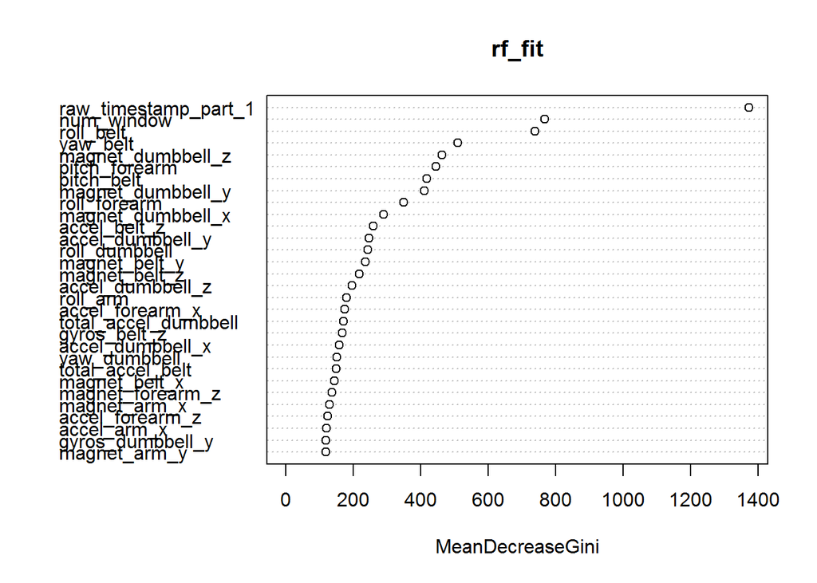

```r
varImpPlot(rf_fit,type=2)
```

## Dataset Reference

Velloso, E.; Bulling, A.; Gellersen, H.; Ugulino, W.; Fuks, H. Qualitative Activity Recognition of Weight Lifting Exercises. Proceedings of 4th International Conference in Cooperation with SIGCHI (Augmented Human ’13) . Stuttgart, Germany: ACM SIGCHI, 2013.